# Human Activity Recognition using Random Forest Machine Learning Algorithm

Andreas Rimbe

June 20, 2015

## Summary

In this course project for [Practial Machine Learning](https://www.coursera.org/course/predmachlearn) on Coursera, a random forest model is built to predict human activity based on the observations in the [Groupware@LES Human Activity Recognition](http://groupware.les.inf.puc-rio.br/har) dataset.

The HAR dataset contains accelerometer data collected from sensors on the belt, forearm, arm, and dumbell from 6 subjects that were asked to perform barbell lifts correctly and incorrectly in 5 different ways (sitting-down, standing-up, standing, walking, and sitting).

A random forest model was built with 250 trees using 5-fold cross-validation and achieved an accuracy on the validation data of 99.47% with an out of sample error of 0.53%.

On the testing dataset, 20 cases was predicted with 100% accuracy.

## Load Data

Training & testing datasets are loaded from [Groupware@LES Human Activity Recognition](http://groupware.les.inf.puc-rio.br/har).

```r
trainFile <- "pml-training.csv"
testFile  <- "pml-testing.csv"

if (!file.exists(trainFile)) {
  download.file("https://d396qusza40orc.cloudfront.net/predmachlearn/pml-training.csv", destfile=trainFile, method="curl")
}

if (!file.exists(testFile)) {
  download.file("https://d396qusza40orc.cloudfront.net/predmachlearn/pml-testing.csv", destfile=testFile, method="curl")
}

training <- read.csv(trainFile)
testing <- read.csv(testFile)
```

## Explore data

```r
d1 <- dim(training); d1
```

```
## [1] 19622   160
```

```r
d2 <- dim(testing); d2
```

```
## [1]  20 160
```

The training data set contains **19622** observations and **160** variables and the test data set contains **20** observations and **160** variables.

The response variable is called `classe` and consists of 5 factors, A-E representing these activities: sitting-down, standing-up, standing, walking, and sitting.

Here’s a summary how the `classe` response looks for the training dataset.

```r
summary(training$classe)
```

```
##    A    B    C    D    E
## 5580 3797 3422 3216 3607
```

## Preprocess Data

**1. Remove varables with NA’s**

The training dataset contains a lot of missing values, so we remove variables with NA’s:

```r
sum(complete.cases(training))
```

```
## [1] 406
```

```r
trainingCleaned <- training[, colSums(is.na(training)) == 0]
dim(trainingCleaned)
```

```
## [1] 19622    93
```

**2. Remove variables with near zero variance**

Variables with unique values e.g zero or near zero variance are removed as they have little or no impact on the response.

```r
nzv <- nearZeroVar(trainingCleaned, saveMetrics=TRUE)
trainingCleaned <- trainingCleaned[, nzv[,"nzv"] == FALSE]
dim(trainingCleaned)
```

```
## [1] 19622    59
```

**3. Remove non-accelerator columns**

There are a few non-accelerator variables we can also remove, such as timestamp, user, window etc.

```r
trainingCleaned <- trainingCleaned[, -grep("timestamp|user_name|new_window|num_window|X", names(trainingCleaned))]
d3 <- dim(trainingCleaned); d3
```

```
## [1] 19622    53
```

The cleaned training dataset now contains **19622** observations and **53** variables.

## Data Model

We’ll now fit a random forest model with 5-fold cross validation for a good bias-variance trade-off. The cleaned training dataset is split 70/30 into a training & validation dataset.

```r
set.seed(1234)
inTrain <- createDataPartition(trainingCleaned$classe, p=0.7, list=FALSE)
trainingData <- trainingCleaned[inTrain,]
validationData <- trainingCleaned[-inTrain, ]

# Use multiple cores for parallel processing
numCores <- detectCores()
registerDoMC(cores = numCores - 1)

modelRF <- train(classe ~ .,
                  data=trainingData, method="rf",
                  trControl=trainControl(method="cv", number=5),
                  prox=TRUE,
                  allowParallel=TRUE,
                  ntree=250)
modelRF
```

```
## Random Forest
##
## 13737 samples
##    52 predictor
##     5 classes: 'A', 'B', 'C', 'D', 'E'
##
## No pre-processing
## Resampling: Cross-Validated (5 fold)
##
## Summary of sample sizes: 10990, 10988, 10991, 10990, 10989
##
## Resampling results across tuning parameters:
##
##   mtry  Accuracy   Kappa      Accuracy SD  Kappa SD
##    2    0.9920653  0.9899620  0.002189019  0.002769802
##   27    0.9922107  0.9901464  0.002177593  0.002754879
##   52    0.9876976  0.9844376  0.004040518  0.005110392
##
## Accuracy was used to select the optimal model using  the largest value.
## The final value used for the model was mtry = 27.
```

### Estimated accuracy & out of sample error of the model

The model is tested on the validation dataset:

```r
predictRF <- predict(modelRF, validationData)
confusionMatrix(validationData$classe, predictRF)
```

```
## Confusion Matrix and Statistics
##
##           Reference
## Prediction    A    B    C    D    E
##          A 1674    0    0    0    0
##          B    9 1129    1    0    0
##          C    0    5 1017    4    0
##          D    0    2    4  957    1
##          E    0    1    1    3 1077
##
## Overall Statistics
##
##                Accuracy : 0.9947
##                  95% CI : (0.9925, 0.9964)
##     No Information Rate : 0.286
##     P-Value [Acc > NIR] : < 2.2e-16
##
##                   Kappa : 0.9933
##  Mcnemar's Test P-Value : NA
##
## Statistics by Class:
##
##                      Class: A Class: B Class: C Class: D Class: E
## Sensitivity            0.9947   0.9930   0.9941   0.9927   0.9991
## Specificity            1.0000   0.9979   0.9981   0.9986   0.9990
## Pos Pred Value         1.0000   0.9912   0.9912   0.9927   0.9954
## Neg Pred Value         0.9979   0.9983   0.9988   0.9986   0.9998
## Prevalence             0.2860   0.1932   0.1738   0.1638   0.1832
## Detection Rate         0.2845   0.1918   0.1728   0.1626   0.1830
## Detection Prevalence   0.2845   0.1935   0.1743   0.1638   0.1839
## Balanced Accuracy      0.9973   0.9954   0.9961   0.9957   0.9990
```

The out of sample error should be low as the random forest algorithm performs cross-validation internally.

```r
oose <- sum(predictRF != validationData$classe) * 100 / nrow(validationData)
```

The estimated accuracy of the model on the validation dataset is **99.47%** and the estimated out of sample error is **0.53%**.

See the appendix for plots of predictor importance, model accuracy for selected predictors and the error rate for the number of trees in the random forest.

## Predition result on the testing dataset

The result of applying the testing dataset on the model:

```r
testData <- testing[, names(testing) %in% names(trainingCleaned)]
predictRFTest <- predict(modelRF, newdata=testData)
predictRFTest
```

```
##  [1] B A B A A E D B A A B C B A E E A B B B
## Levels: A B C D E
```

## Conclusion

The selected random forest model was able to predict **100%** of the 20 cases provided in the testing dataset.

## Appendix

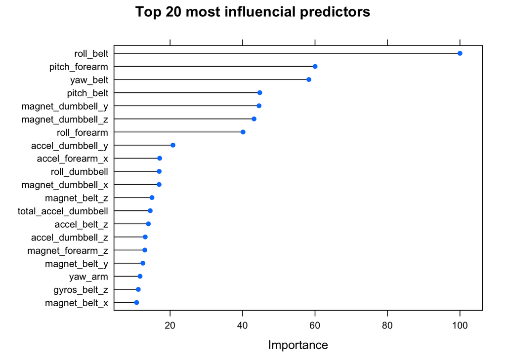

```r
vi <- varImp(modelRF)
plot(vi, main = "Top 20 most influencial predictors", top = 20)
```

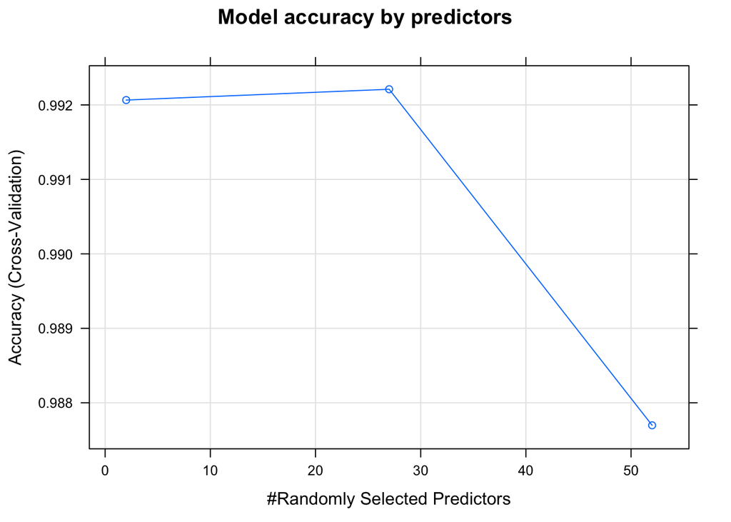

```r
plot(modelRF, main="Model accuracy by predictors")
```

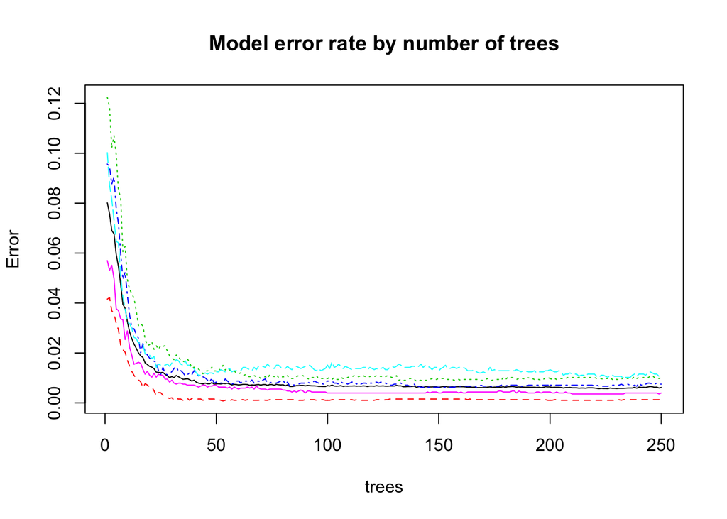

```r
plot(modelRF$finalModel, main="Model error rate by number of trees")
```